# Heart Disease EDA

Dave Riley

11/11/2018

## Predicting Heart Disease competition on DrivenData.org

This is an R Markdown document that will be my inital attempt at a few things in R including:  
* Setting up an environment in R Studio  
* Working in R markdown with proper documentation  
* Extract, transform, and load data  
* Working with data.table, NOT data.frame  
* EDA  
* Some maching learning  
* Exporting the format correctly for the competition

The link below is to the competition: https://www.drivendata.org/competitions/54/machine-learning-with-a-heart/page/107/.

## Importing and transforming the data

First importing data as data.frames, converting to data.tables and then merge on patient_id to have a single table.

I spent a few hours chasing my tail due to my confusion between tables and frames. Frames are default, but tables may be faster. I have a cheatsheet for data.tables.

Taking a few minutes to view the summary statistics for anything that pops out. So far, it looks like gender is worth digging into.

```r
library(data.table)
train_labels <- read.csv('train_labels.csv')
train_values <- read.csv('train_values.csv')
merged_train <- merge(train_labels, train_values, by = "patient_id")
DT <- as.data.table(merged_train)
summary(DT)
```

```
##    patient_id  heart_disease_present slope_of_peak_exercise_st_segment
##  02cipp :  1   Min.   :0.0000        Min.   :1.00
##  08usun :  1   1st Qu.:0.0000        1st Qu.:1.00
##  0g192k :  1   Median :0.0000        Median :1.00
##  0n5fu0 :  1   Mean   :0.4444        Mean   :1.55
##  0ryxtv :  1   3rd Qu.:1.0000        3rd Qu.:2.00
##  0xw93k :  1   Max.   :1.0000        Max.   :3.00
##  (Other):174
##                 thal    resting_blood_pressure chest_pain_type
##  fixed_defect     : 8   Min.   : 94.0          Min.   :1.000
##  normal           :98   1st Qu.:120.0          1st Qu.:3.000
##  reversible_defect:74   Median :130.0          Median :3.000
##                         Mean   :131.3          Mean   :3.156
##                         3rd Qu.:140.0          3rd Qu.:4.000
##                         Max.   :180.0          Max.   :4.000
##
##  num_major_vessels fasting_blood_sugar_gt_120_mg_per_dl
##  Min.   :0.0000    Min.   :0.0000
##  1st Qu.:0.0000    1st Qu.:0.0000
##  Median :0.0000    Median :0.0000
##  Mean   :0.6944    Mean   :0.1611
##  3rd Qu.:1.0000    3rd Qu.:0.0000
##  Max.   :3.0000    Max.   :1.0000
##
##  resting_ekg_results serum_cholesterol_mg_per_dl oldpeak_eq_st_depression
##  Min.   :0.00        Min.   :126.0               Min.   :0.00
##  1st Qu.:0.00        1st Qu.:213.8               1st Qu.:0.00
##  Median :2.00        Median :245.5               Median :0.80
##  Mean   :1.05        Mean   :249.2               Mean   :1.01
##  3rd Qu.:2.00        3rd Qu.:281.2               3rd Qu.:1.60
##  Max.   :2.00        Max.   :564.0               Max.   :6.20
##
##       sex              age        max_heart_rate_achieved
##  Min.   :0.0000   Min.   :29.00   Min.   : 96.0
##  1st Qu.:0.0000   1st Qu.:48.00   1st Qu.:132.0
##  Median :1.0000   Median :55.00   Median :152.0
##  Mean   :0.6889   Mean   :54.81   Mean   :149.5
##  3rd Qu.:1.0000   3rd Qu.:62.00   3rd Qu.:166.2
##  Max.   :1.0000   Max.   :77.00   Max.   :202.0
##
##  exercise_induced_angina
##  Min.   :0.0000
##  1st Qu.:0.0000
##  Median :0.0000
##  Mean   :0.3167
##  3rd Qu.:1.0000
##  Max.   :1.0000
##
```

```r
sapply(DT, class)
```

```
##                           patient_id                heart_disease_present
##                             "factor"                            "integer"
##    slope_of_peak_exercise_st_segment                                 thal
##                            "integer"                             "factor"
##               resting_blood_pressure                      chest_pain_type
##                            "integer"                            "integer"
##                    num_major_vessels fasting_blood_sugar_gt_120_mg_per_dl
##                            "integer"                            "integer"
##                  resting_ekg_results          serum_cholesterol_mg_per_dl
##                            "integer"                            "integer"
##             oldpeak_eq_st_depression                                  sex
##                            "numeric"                            "integer"
##                                  age              max_heart_rate_achieved
##                            "integer"                            "integer"
##              exercise_induced_angina
##                            "integer"
```

# Gender comparison plot

Using ggplot2 we can build a baseline predictive model based on gender alone. It appears that of people with heart disease (n=80), almost 70 are men.

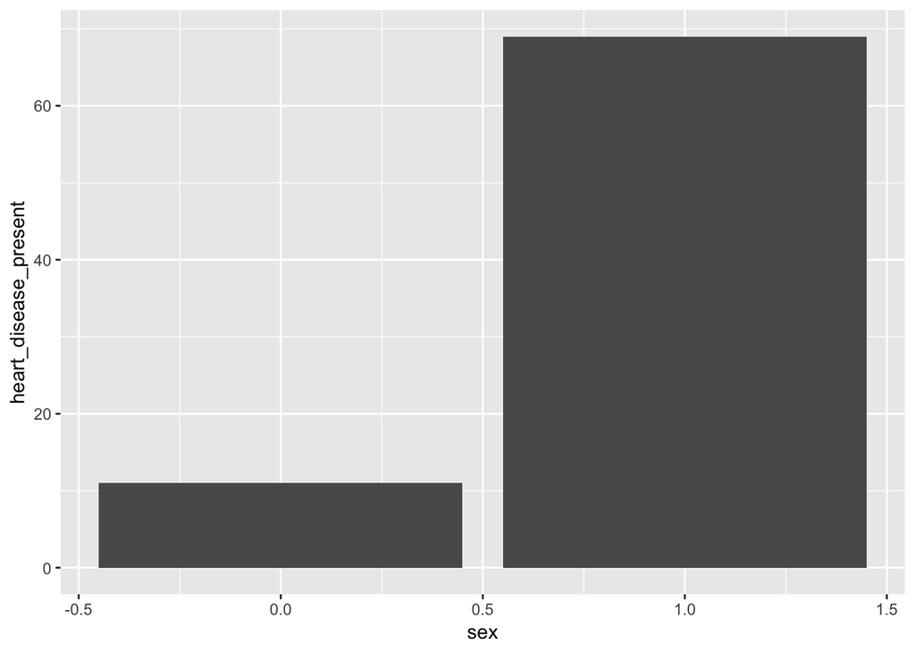

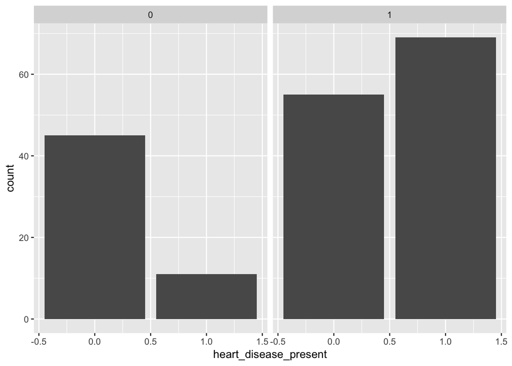

## Several plots versus age. Heart disease present showed a few interesting areas to explore.

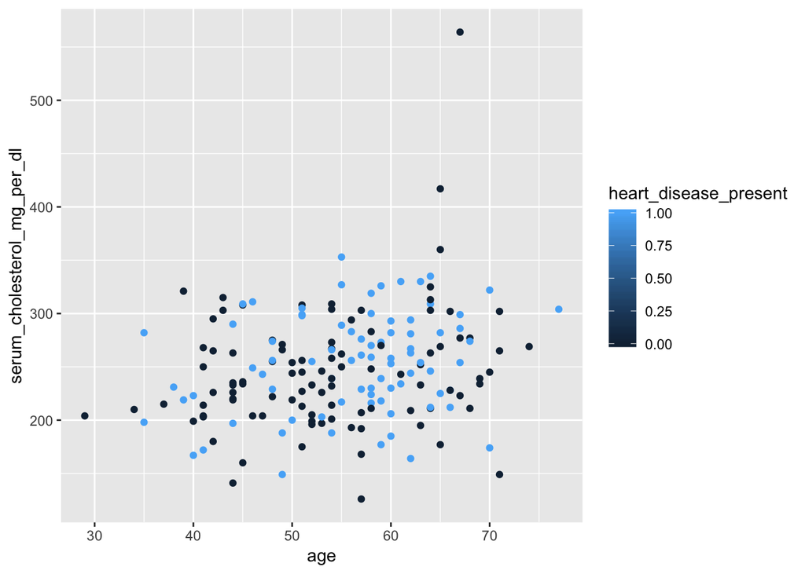

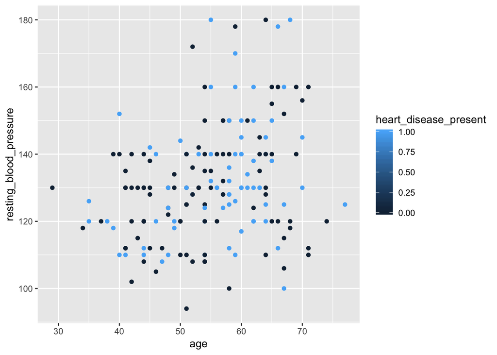

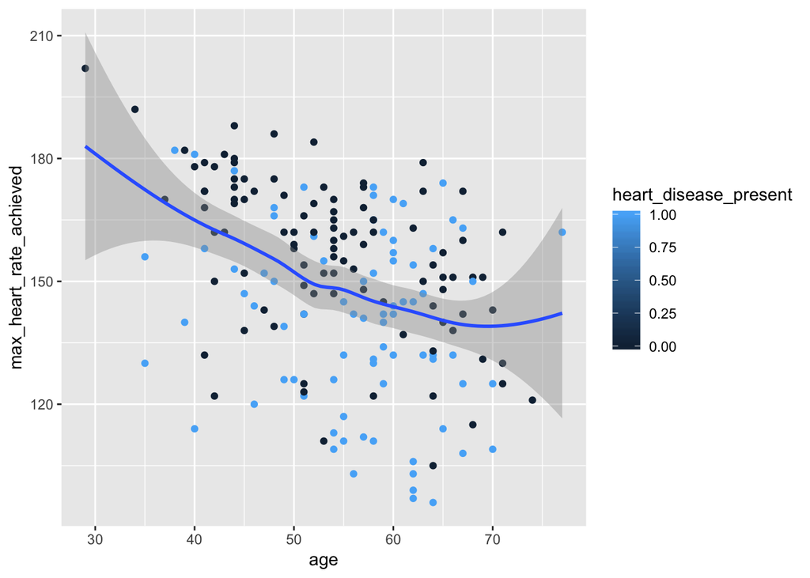

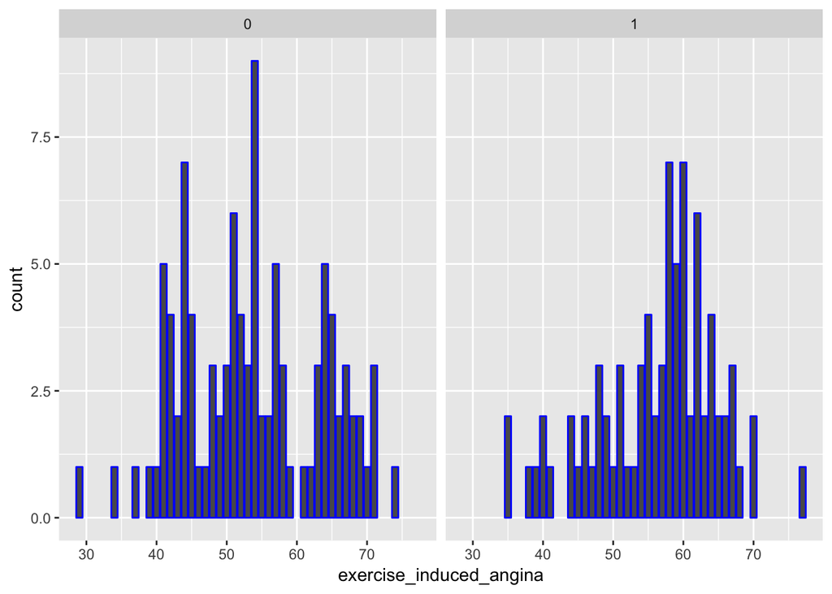

## Need to look up corrpolt for the plot of the correlation matrix that was made.

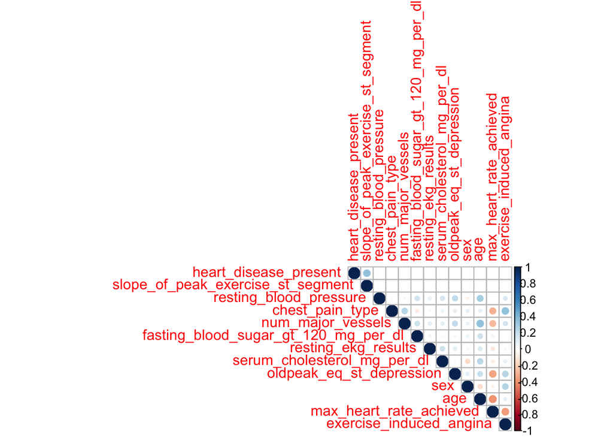

```r
library("corrplot")
cor_variables <- merge(c(DT[,2:3]), c(DT[,5:15]))
cor_matrix <- round(cor(cor_variables), 3)
corrplot(cor_matrix, type = "upper")
```

# Histograms of various categorical data - tried to find a way to feed a vector and/or use lapply, but was unable to do so. saved a variable called “categorical_variables”

- I also need to label these better and possible try to find a way to loop these.

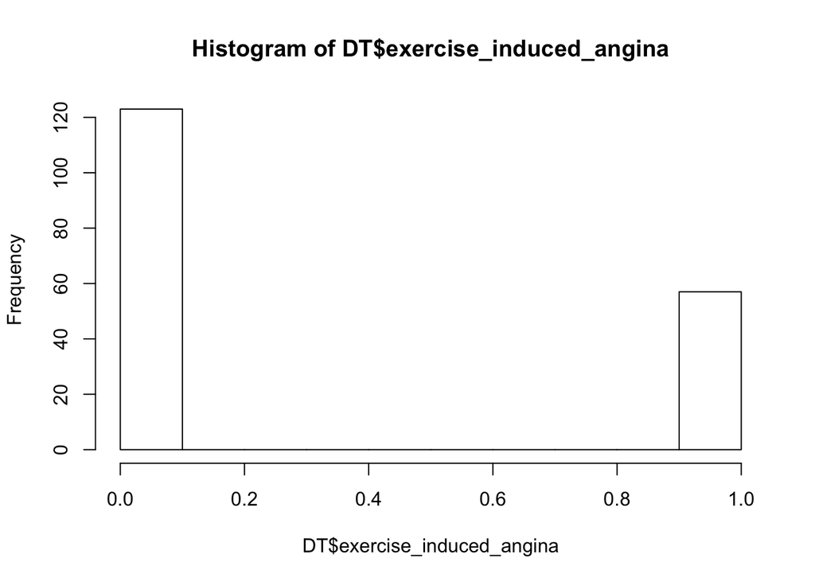

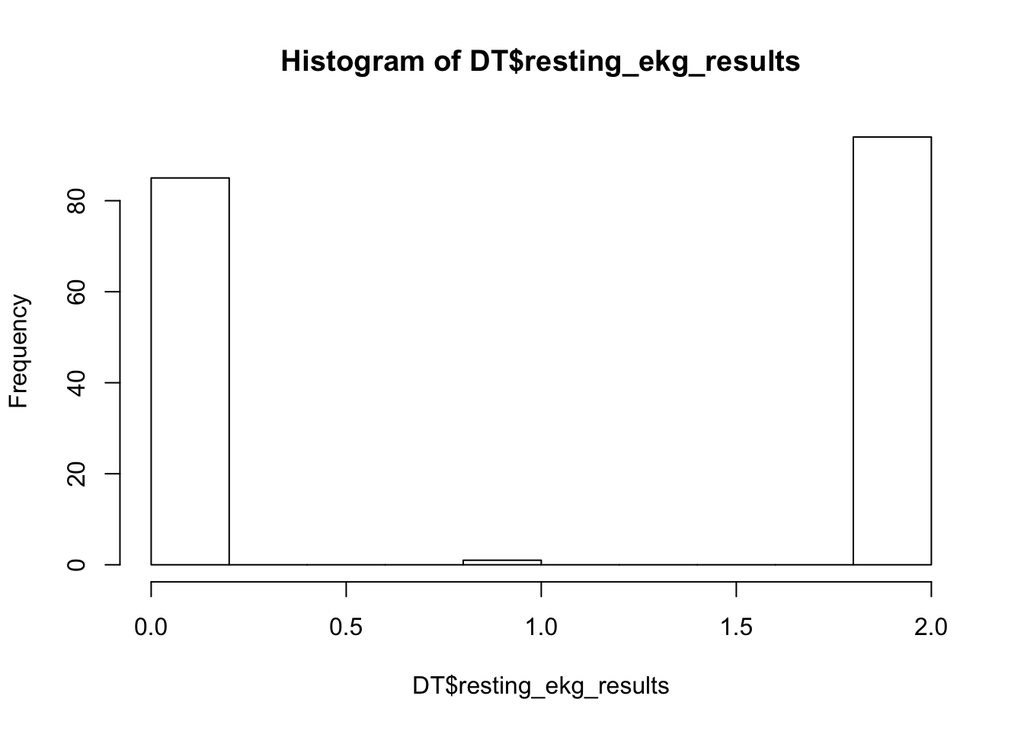

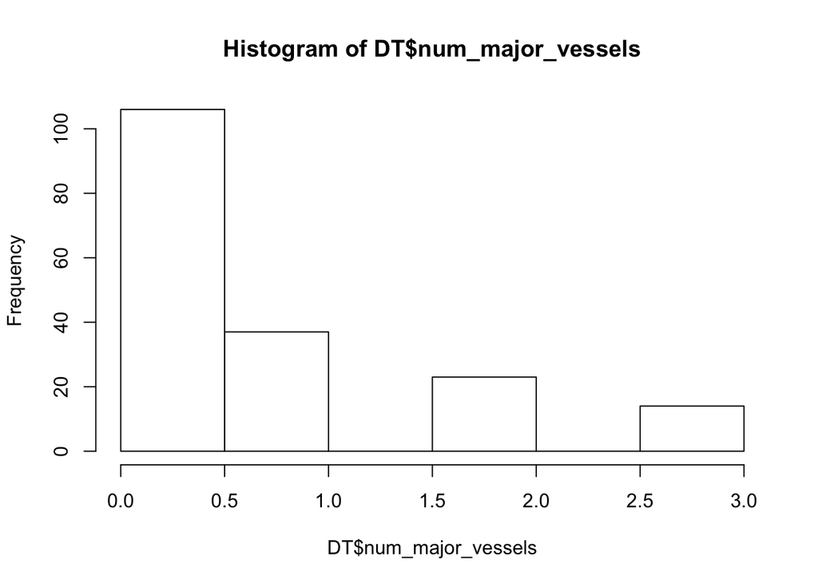

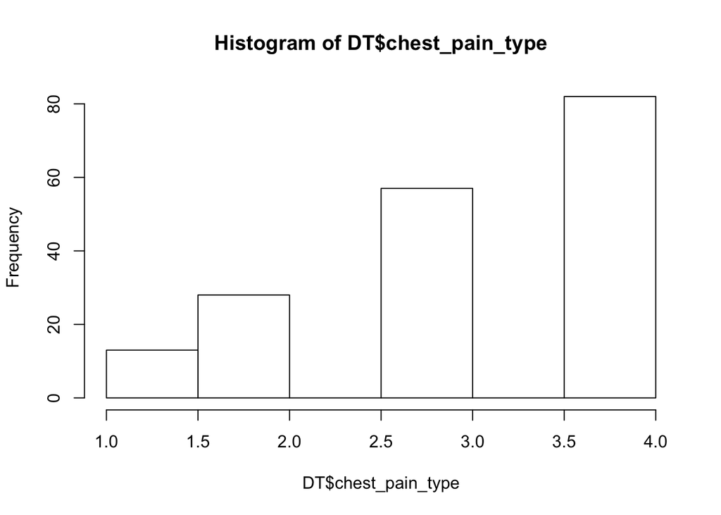

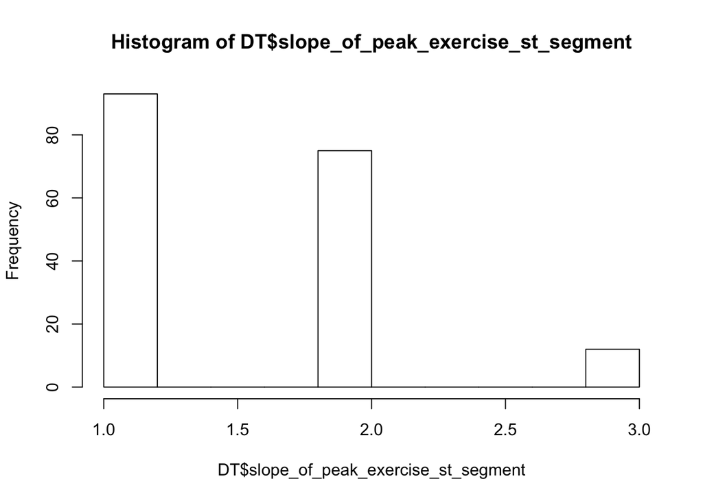

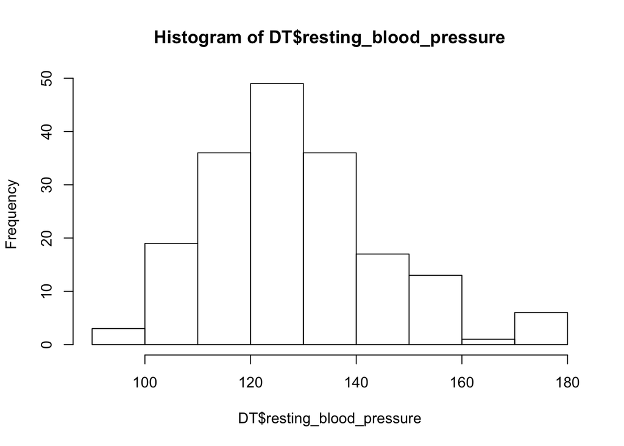

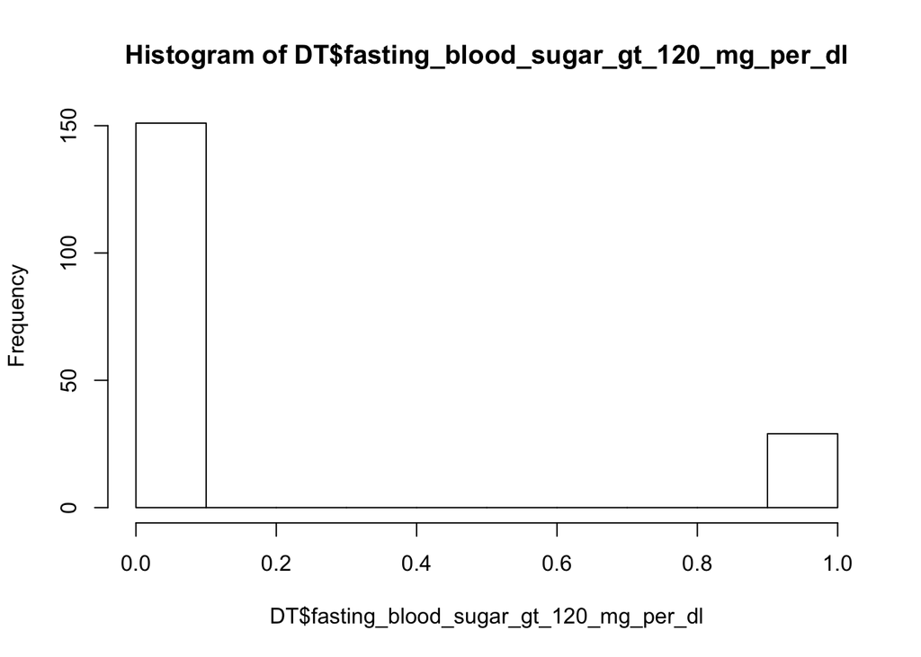

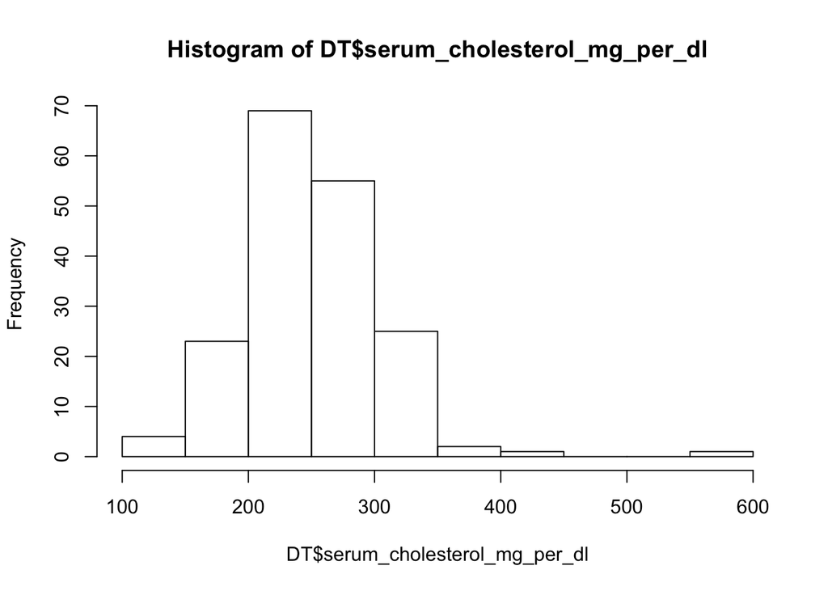

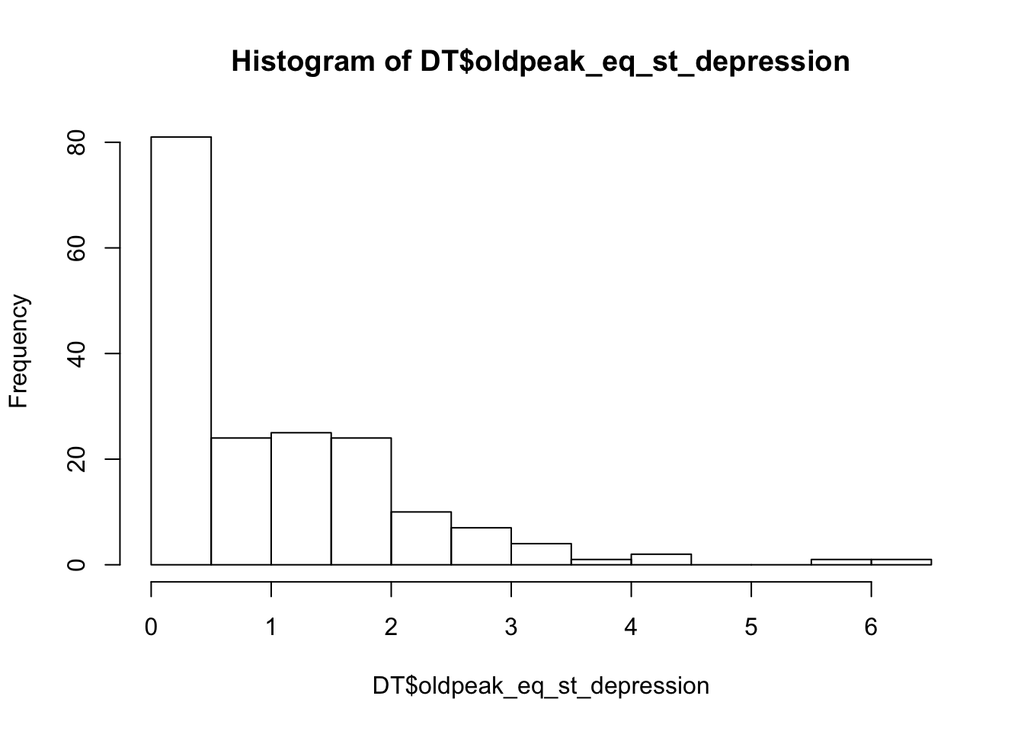

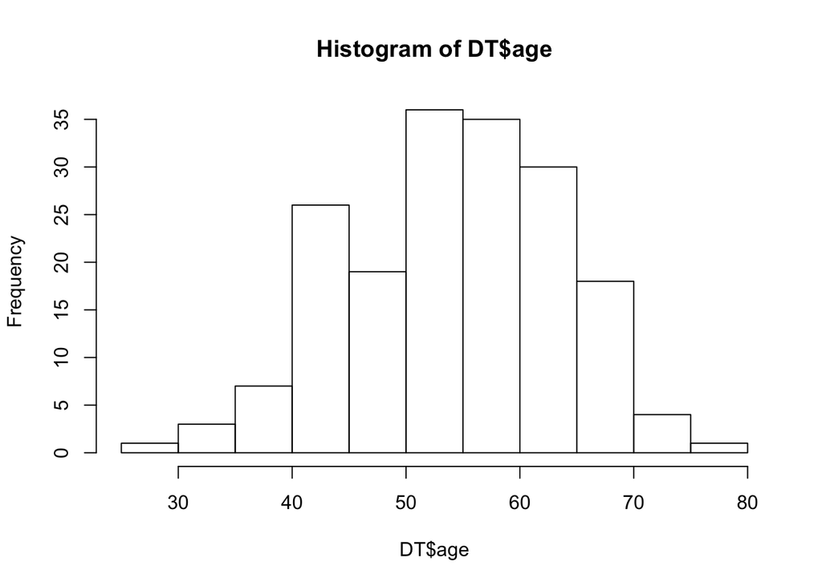

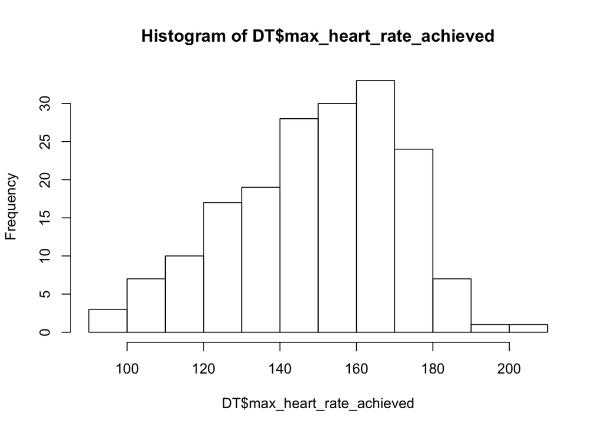